# MDAG workshop: Part 4c Git and GitHub

Author

J Nienkemper-Swanepoel

# Background

- Part 4 of the MDAG workshop will show you how to create a website using **Quarto** and **GitHub** with no knowledge of **Git**.
- However, in the long run it would greatly benefit your workflow to acquire skills in **Git**.
- **Git** and **GitHub** are crucial for collaborative projects.
- This document is a first step to your future with **Git** and **GitHub**.
- The steps are easy to follow and will definitely be worth it in the end.
- We encourage you to give this a try!!

### Installing Git

The Bash shell is the preferred way to communicate between **Git** and **GitHub**.  
In computing, `bash` refers to a program that allows command-line interface. Therefore, Git-bash provides a command-line environment to submit documents and projects to **GitHub** (more information on this later).

- You will have to install: Git
  - For MacOS: You do not have to install anything, Bash is available from the Terminal (`/Applications/Utilities`).
  - For Linux: Git is possibly already available, if not install via your `distro`’s package manager. For `Debian/Ubuntu` run `sudo apt-get install git` and for `Fedora` run `sudo dnf install git`. For more information: [Carpentries website](https://carpentries.github.io/workshop-template/install_instructions/#git)
  - For Windows: **Git Bash** is preferred. Download this from [git for windows](https://gitforwindows.org/). The **carpentries** website provides complete [Shell installation instructions](https://carpentries.github.io/workshop-template/install_instructions/#shell) and a video tutorial. **FOLLOW ALL THESE STEPS DILIGENTLY,** accept for Step 2.2 where you may select a text editor you are familiar with.

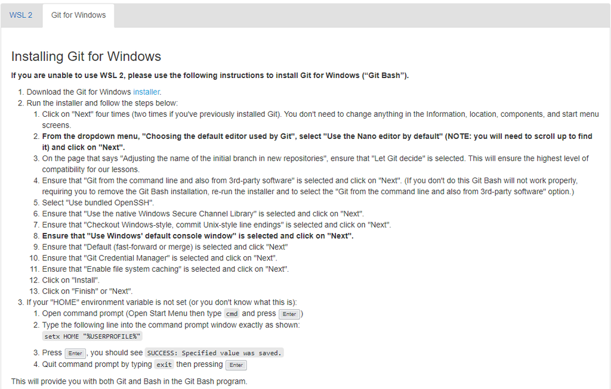

    Once installed, `Git bash` will be available in your programme list:

[figure not shown]

When you open this application a similar screen will appear:

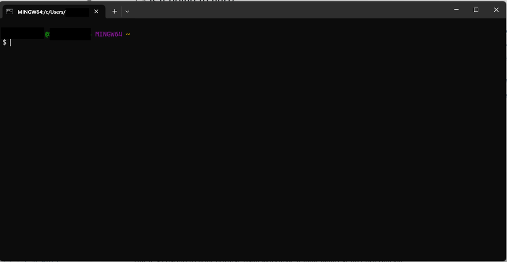

Now, you will have to configure `git` the first time it is used on a computer. This will include configuring:

- your username and email address (same address as your **GitHub** account)
- specifying your preferred text editor (this is very useful when you run into conflicts with different versions of your documents)
- set the settings to be used globally (i.e. for all projects).

Type the following in **Git Bash**:

- Change your name and surname and press **enter**: `git config --global user.name "Your name and surname"`
- Change your email address to the GitHub account email address and press **enter**: `git config --global user.email "email@domain"`

Further reading: [Software Carpentry: Version Control with Git](https://swcarpentry.github.io/git-novice/)

#### Setting up your working directory

- Decide where you are going to save your repositories / folders locally. I have a dedicated ‘Repositories’ folder under ‘Documents’. This destination is entirely up to you, just ensure you know where to find it again.

[figure not shown]

# Workshop specific steps

At this stage it is assumed that the **Git** and **GitHub** steps have been completed. If you have already created the copy of the template as explained in `Part 4b`, you can skip step 1 to 3.

- **Step 1**: Sign into your **GitHub** account.
- **Step 2**: Search for the [MDAG workshop website template](https://github.com/jnienk/createQuarto_website/tree/main). Click on **Use this template** and **Create a new repository**:

[figure not shown]

- **Step 3**: Specify a repository name and **Create repository**:

[figure not shown]

*You will have to keep the visibility of the repository **Public** for the website to render.*  
You will see the following screen once you have selected **Create repository**.

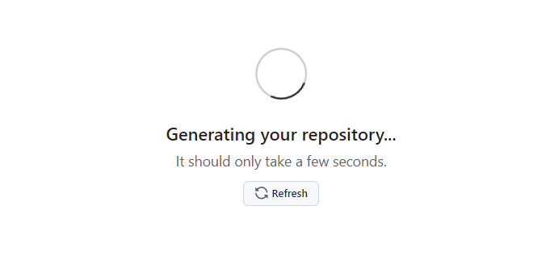

- **Step 4**: Click on **Code** and under the **HTTPS** panel click **Copy url to clipboard**.

[figure not shown]

- **Step 5**: Open `RStudio`.
- **Step 6**: Create a **New Project**.

[figure not shown]

- **Step 7**: Select **Version Control**:

[figure not shown]

- **Step 8**: Select **Git**:

[figure not shown]

- **Step 9**: Paste the `url` you have copied in Step 4. Typically, the project directory name will automatically be filled in, but if this does not happen you can type the name of the GitHub repository you have specified. Change the subdirectory to the working directory you have created for repositories (eg. …Documents > Repositories).

[figure not shown]

- **Step 10**: To practice the `commit` procedure, make a small change to the `README.md` file. For example:

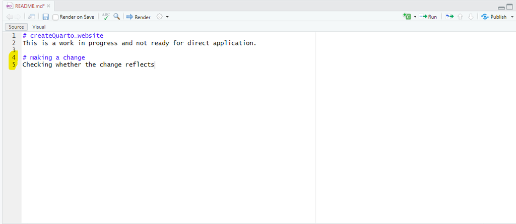

- **Step 11**: Commit this change by selecting **Git** in the `Environment / History` window. Select the file that has been changed (for this example, only README.md) and click on **commit**.

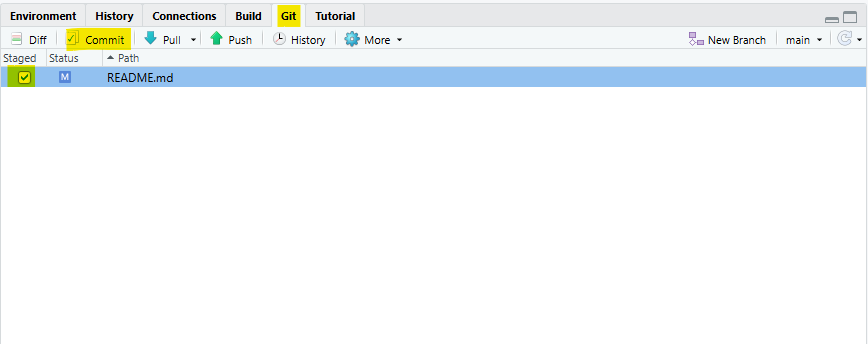

- **Step 12**: A window will open to allow a message to be added. Be concise and descriptive as this could be useful to keep track of future changes.

[figure not shown]

- **Step 13**: Close the **Git Commit** window:

[figure not shown]

- **Step 14**: Click **push** to sync these changes with the online **GitHub** version.

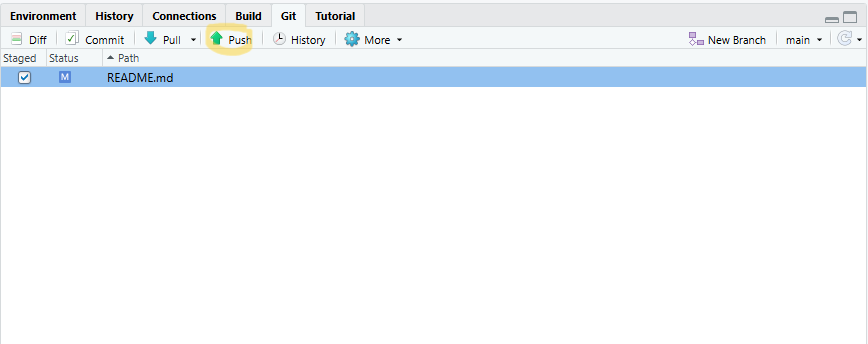

[figure not shown]

- **Step 15**: If this is your first time using **GitHub**, you will be asked to **Connect to GitHub** since you have to setup a secure shell (SSH). You will only have to do this once. More information on [SSH](https://docs.github.com/en/authentication/connecting-to-github-with-ssh/about-ssh).

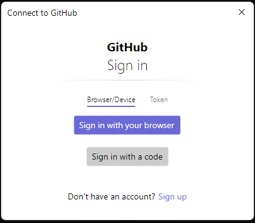

- **Step 16**: Once you are signed in to your account, navigate towards your repository copy of the **createQuarto_website** template. If you see the following by selecting **Code** and **SSH**, you will have to add a public key by following steps 17 to 22.

[figure not shown]

- **Step 17**: Select **SSH and GPG keys** under your profile settings and click on **New SSH key**.

[figure not shown]

[figure not shown]

- **Step 18**: Now open **Git Bash** and type the following by only changing your account email address and press **Enter**: `ssh-keygen -t ed25519 -C "mymail@emaildomain.com"`

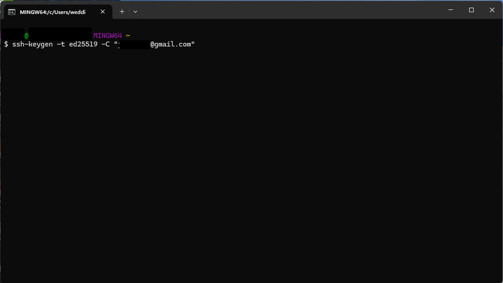

This will generate a key and it will disclose the destination of these files in the terminal (see an example below):

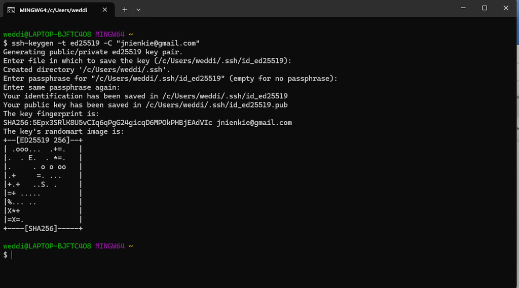

- **Step 19**: Navigate towards the destination where the key is saved. There will be two documents that can be opened by selecting a text editor when clicking **Open with**. The two documents contain different information, you require the document that contains information that starts with ‘ssh-ed25519’ and ends with your account email address. Copy this and open the browser with **GitHub** again.
- **Step 20**: Add a Title for your key (this can be anything) and paste the information in the **Key** text box. Finally, click **Add SSH key**.

[figure not shown]

- **Step 21**: This will ask you for a Git authorisation. Click on **Git Credential Manage by Git Ecosystem** followed by **Authorize git-ecosystem**.
- **Step 22**: This should be quickly followed by a successful authentication:

[figure not shown]

- **Step 23**: Now, back to RStudio, you can attempt to **push** the changes again and should be followed by a similar message box:

[figure not shown]

- **Step 24**: Refresh your browser where **GitHub** is open. You should see the commit message next to your **README.md** file:

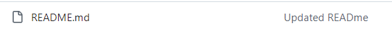

## Working in `Git Bash` / `terminal`

- Using `RStudio` for version control is typically easier when you are starting out.
- However, if you expand your projects beyond `R`, it would be useful to familiarise yourself with `Git`.

Open **Git Bash** and change the `current directory` to your `Repositories` folder by using `cd` **space** followed by the path.

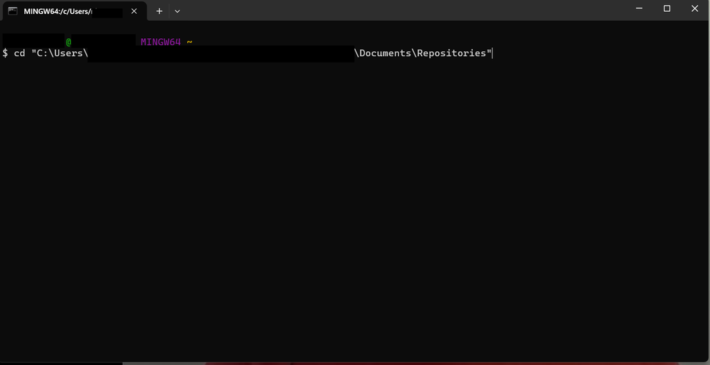

- Press **enter**. The current directory should now point towards the `Repositories` folder:

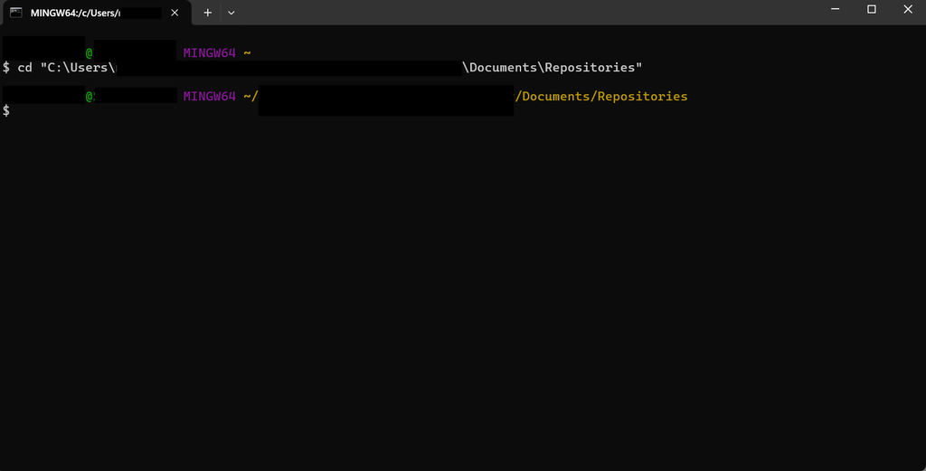

- You can now use commands such as `git status`, `git pull`, `git add`, `git commit -m "message"` and`git push`.
- `Git` functionalities are beyond the scope of this workshop, please refer to the following useful resources for further reading:
  - [Version control RStudio](https://docs.posit.co/ide/user/ide/guide/tools/version-control.html)
  - [Git vs RStudio GUI](https://r4bds.github.io/primer_git_cli.html)
  - [Git and GitHub with RStudio](https://valentinlucet.com/git-and-github-with-r-workshop/)